# Dimensionality Reduction for Pizza Data from Pizza Hut

## Introduction

### Pizza is a very common food. As one of the larger chain stores, pizza hut also has a lot in the Polish market, so I want to retain as much useful information as possible by reducing the dimensionality of the nutritional content of pizza. Data source is https://ocs-pl.oktawave.com/v1/AUTH_876e5729-f8dd-45dd-908f-35d8bb716177/amrest-web-ordering/GRD4/nutrition/Nutrition%20ALL%20CONCEPTS%20FINAL_W1.2019.pdf. The data has been preprocessed before processing the data, and some unimportant information has been deleted.

## Dataframe

### Some basic information of the dataframe

```r
library(corrplot)
library(factoextra)
library(dplyr)


PizzaData <- read.csv("Nutrition pizza from pizza hut.csv")
dim(PizzaData)
```

```
## [1] 63  8
```

```r
head(PizzaData)
```

```
##                   Produkt Kcal.100g fat.g.100g saturated.fatty.acid.g.100g
## 1     Pizza Pan-Pepperoni       291       14.3                         6.1
## 2    Pizza Pan-Margherita       256       11.4                         4.1
## 3     Pizza Pan-Americana       236       10.6                         4.4
## 4      Pizza Pan-Hawajska       237       10.2                         4.2
## 5       Pizza Pan-Supreme       266       13.7                         6.0
## 6 Pizza Pan-Super Supreme       247       12.8                         5.6
##   carbohydrate.g.100g sugar.g.100g protein.g.100g salt.g.100g
## 1                27.7          2.2           12.7         1.5
## 2                29.5          2.9           11.2         1.1
## 3                25.0          3.3           10.4         1.1
## 4                25.0          4.2           11.3         1.3
## 5                23.5          1.9           12.3         1.4
## 6                19.7          1.6           13.1         1.6
```

```r
summary(PizzaData)
```

```
##    Produkt            Kcal.100g       fat.g.100g    saturated.fatty.acid.g.100g
##  Length:63          Min.   :201.0   Min.   : 5.80   Min.   : 2.200
##  Class :character   1st Qu.:232.0   1st Qu.: 8.80   1st Qu.: 4.400
##  Mode  :character   Median :256.0   Median :10.80   Median : 5.500
##                     Mean   :253.7   Mean   :10.74   Mean   : 6.011
##                     3rd Qu.:278.0   3rd Qu.:12.15   3rd Qu.: 6.850
##                     Max.   :315.0   Max.   :15.30   Max.   :34.000
##  carbohydrate.g.100g  sugar.g.100g   protein.g.100g   salt.g.100g
##  Min.   :17.9        Min.   :1.600   Min.   : 9.20   Min.   :0.870
##  1st Qu.:23.1        1st Qu.:2.500   1st Qu.:11.80   1st Qu.:1.195
##  Median :24.4        Median :2.900   Median :13.10   Median :1.280
##  Mean   :25.1        Mean   :3.067   Mean   :13.47   Mean   :1.273
##  3rd Qu.:27.7        3rd Qu.:3.400   3rd Qu.:15.10   3rd Qu.:1.380
##  Max.   :33.9        Max.   :6.300   Max.   :19.60   Max.   :1.600
```

### Histogram for each column of data

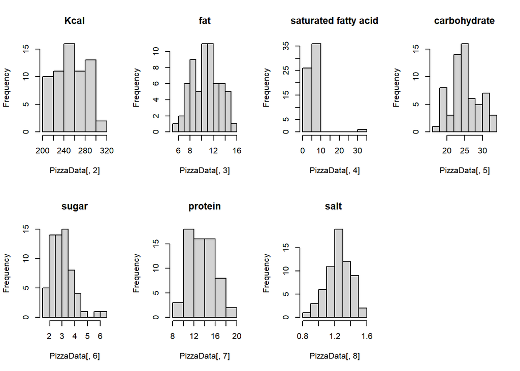

```r
par(mfrow = c(2, 4))
hist(PizzaData[,2],main = "Kcal")
hist(PizzaData[,3],main = "fat")
hist(PizzaData[,4],main = "saturated fatty acid")
hist(PizzaData[,5],main = "carbohydrate")
hist(PizzaData[,6],main = "sugar")
hist(PizzaData[,7],main = "protein")
hist(PizzaData[,8],main = "salt ")
par(mfrow = c(1, 1))
```

### Correlation Matrix

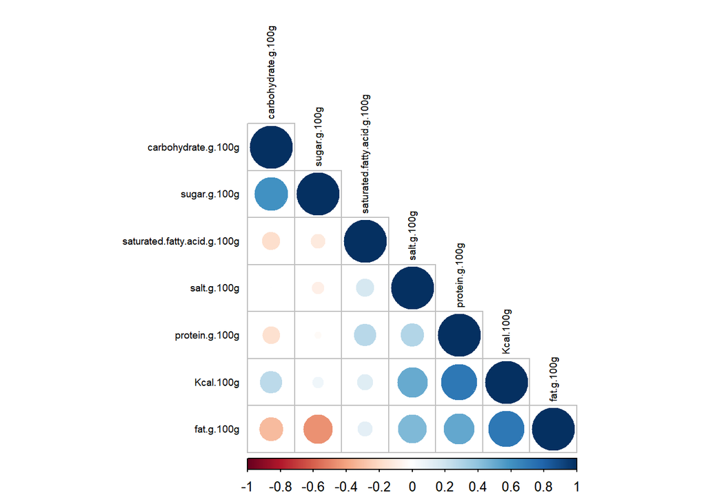

```r
PizzaData1 <- scale(PizzaData[,2:8],center=T,scale=F)
cor<-cor(PizzaData1,method="pearson")
corrplot(cor, type = "lower", order = "hclust", tl.col = "black", tl.cex = 0.6)
```

## Principal Component Analysis (PCA)

### Optimal number of components

```r
pca <- prcomp(PizzaData1, center=FALSE)
summary(pca)
```

```
## Importance of components:
##                            PC1     PC2     PC3     PC4     PC5     PC6     PC7
## Standard deviation     28.8065 4.47426 3.54852 1.62802 0.68500 0.50454 0.12541
## Proportion of Variance  0.9584 0.02312 0.01454 0.00306 0.00054 0.00029 0.00002
## Cumulative Proportion   0.9584 0.98154 0.99608 0.99915 0.99969 0.99998 1.00000
```

```r
eig.val <- get_eigenvalue(pca)
eig.val
```

```
##         eigenvalue variance.percent cumulative.variance.percent
## Dim.1 829.81242340     95.841953634                    95.84195
## Dim.2  20.01899124      2.312160166                    98.15411
## Dim.3  12.59196345      1.454350819                    99.60846
## Dim.4   2.65044574      0.306122071                    99.91459
## Dim.5   0.46923058      0.054195350                    99.96878
## Dim.6   0.25456053      0.029401318                    99.99818
## Dim.7   0.01572874      0.001816643                   100.00000
```

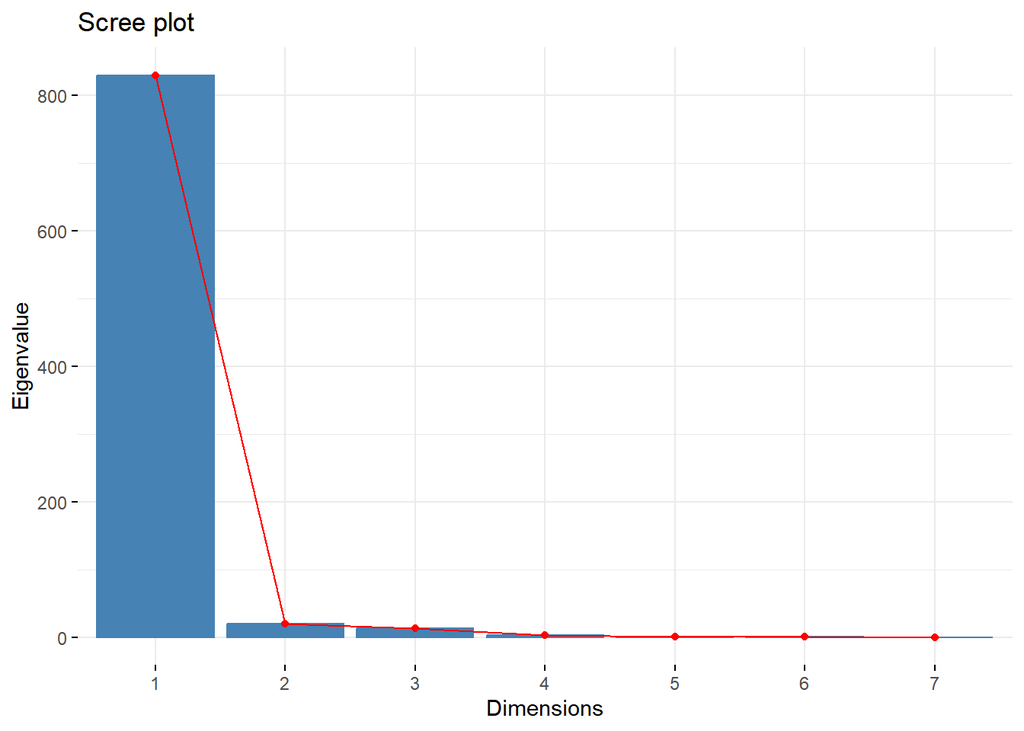

```r
fviz_eig(pca, choice='eigenvalue',linecolor = "red")
```

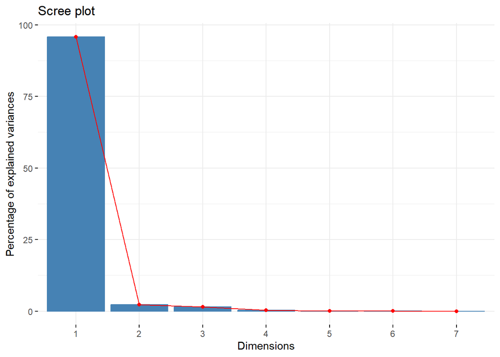

```r
fviz_eig(pca,linecolor = "red")
```

### Through two methods, we can see that the optimal component is one. One component can explain 95% of the data

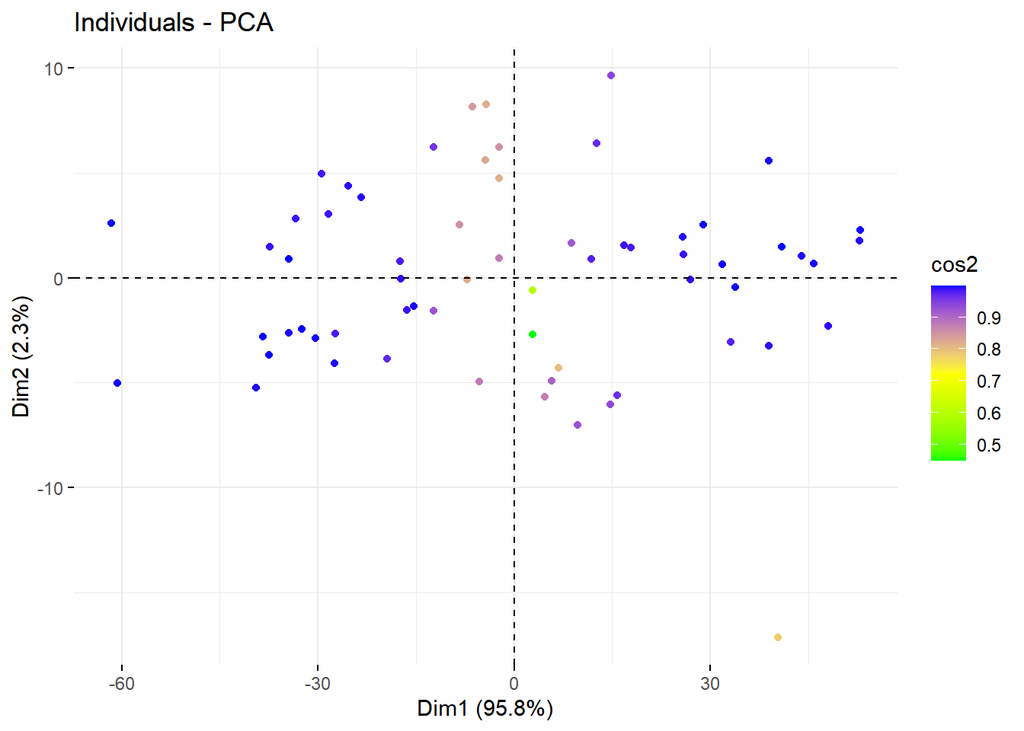

```r
fviz_pca_ind(pca, col.ind="cos2", geom = "point", gradient.cols = c("green", "yellow", "blue" ))
```

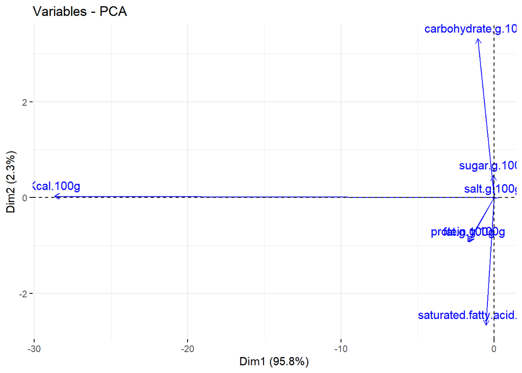

```r
fviz_pca_var(pca, col.var = "blue")
```

### The above figures show the relationship between the variable and other variables, the best variable is Kcal

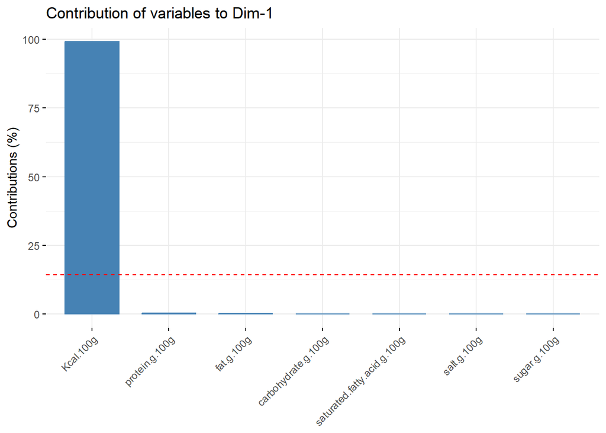

```r
PC1 <- fviz_contrib(pca, choice = "var", axes = 1)
PC2 <- fviz_contrib(pca, choice = "var", axes = 2)
plot(PC1)
```

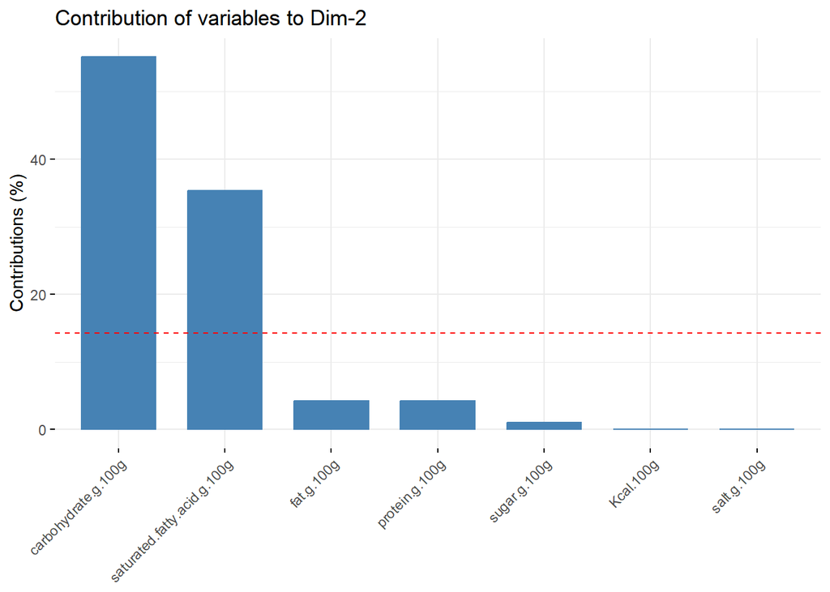

```r
plot(PC2)
```

### The figure above shows that if it is one-dimensional data, Kcal is the best choice. For two-dimensional, carbohydrate and saturated fatty acid are the best choices

## Conclusions

### Dimensionality reduction is very helpful for big data analysis. When resources and practices are limited, dimensionality reduction can screen out useful information to the greatest extent